# R workshop: data check and data cleaning tips

Lan Zhou

2025/5/30

# 1 Abstract

This workshop introduces best practices for writing reproducible and maintainable R code, including using RStudio, organizing code in R Notebooks, and performing data cleaning efficiently.

# 2 Preparation

## 2.1 load packages

```r
library(haven)
library(openxlsx)
library(dplyr)
library(tidyverse)
```

```r
library(ggplot2)
library(here)
library(table1)
```

## 2.2 set seeds

The set. seed( ) function in R ensures that random number generation is consistent across different sessions, allowing for identical results each time the code is executed. This is particularly important when sharing code with others or when results need to be verified.

```r
set.seed(123)
```

## 2.3 use relative path

If you use relative path, your code can work on any computer, not just your own. Great for team projects or sharing your code (e.g., via GitHub or email).

```r
setwd("C:/Users/Lauren/Desktop/CNC-R_course-main/")

here::here()   # Check where here() thinks the root is
```

```
## [1] "C:/Users/Lauren/Desktop/CNC-R_course-main"
```

## 2.4 read data

- data naming rules: consistent, clear, easy to track, cannot start from number, avoid special mark
- read.csv(), to read csv file
- read.xlsx(), to read excel file
- read_sav() , to read SPSS file
- You can also import dataset by clicking the “Import Dataset” in the area of Environment!

```r
df_BIS <- read.csv(here("data","SUDMEX_BIS.csv"))
df_BIS_dict <- read.xlsx(here("data","SUDMEX_BIS.xlsx"))    # only read the first sheet by default
df_BIS_data <- read.xlsx(here("data","SUDMEX_BIS.xlsx"),sheet = "data")   # read different sheets

df_HDRS <- read.csv(here("data","SUDMEX_HDRS.csv"))
```

# 3 Preview data

## 3.1 check the first few rows

```r
head(df_BIS)
```

|  | rid | group | stage | q1 | q2 | q3 | q4 | q5 | q6 | q7 | q8 | q9 | q10 | q11 | q12 | q13 | q14 | q15 | q16 | q17 | q18 | q19 | q20 | q21 | q22 | q23 | q24 | q25 | q26 | … |
| --- | --- | --- | --- | --- | --- | --- | --- | --- | --- | --- | --- | --- | --- | --- | --- | --- | --- | --- | --- | --- | --- | --- | --- | --- | --- | --- | --- | --- | --- | --- |
| 1 | 1 | 1 | T0 | 0 | 4 | 0 | 4 | 4 | 0 | 0 | 0 | 0 | 0 | 4 | 0 | 0 | 1 | 0 | 0 | 0 | 4 | 0 | 0 | 4 | 0 | 4 | 1 | 4 | 1 | … |
| 2 | 1 | 1 | T1 | 0 | 1 | 0 | 4 | 3 | 1 | 0 | 0 | 0 | 0 | 1 | 1 | 0 | 0 | 3 | 4 | 0 | 4 | 0 | 0 | 3 | 3 | 3 | 3 | 1 | 1 | … |
| 3 | 1 | 1 | T4 | 4 | 1 | 0 | 4 | 0 | 0 | 0 | 4 | 1 | 1 | 4 | 4 | 4 | 0 | 4 | 1 | 0 | 4 | 0 | 0 | 0 | 1 | 1 | 4 | 0 | 0 | … |
| 4 | 2 | 1 | T0 | 4 | 1 | 4 | 4 | 4 | 4 | 3 | 4 | 4 | 1 | 3 | 4 | 4 | 0 | 4 | 3 | 0 | 4 | 1 | 1 | 4 | 4 | 4 | 4 | 0 | 4 | … |
| 5 | 2 | 1 | T1 | 4 | 3 | 4 | 4 | 4 | 3 | 1 | 4 | 4 | 3 | 3 | 3 | 4 | 0 | 4 | 4 | 1 | 4 | 1 | 0 | 1 | 4 | 3 | 3 | 0 | 4 | … |
| 6 | 2 | 1 | T1-4 | 4 | 0 | 4 | 4 | 4 | 4 | 3 | 3 | 4 | 3 | 3 | 3 | 4 | 0 | 4 | 0 | 0 | 3 | 3 | 0 | 1 | 3 | 3 | 0 | 0 | 3 | … |

```r
names(df_BIS)   # check the variable names
```

```
##  [1] "rid"       "group"     "stage"     "q1"        "q2"        "q3"
##  [7] "q4"        "q5"        "q6"        "q7"        "q8"        "q9"
## [13] "q10"       "q11"       "q12"       "q13"       "q14"       "q15"
## [19] "q16"       "q17"       "q18"       "q19"       "q20"       "q21"
## [25] "q22"       "q23"       "q24"       "q25"       "q26"       "q27"
## [31] "q28"       "q29"       "q30"       "cog"       "mot"       "nonp"
## [37] "tot_score"
```

## 3.2 View the data structure and data types

```r
str(df_BIS)
```

```
## 'data.frame':    153 obs. of  37 variables:
##  $ rid      : int  1 1 1 2 2 2 2 2 2 3 ...
##  $ group    : int  1 1 1 1 1 1 1 1 1 2 ...
##  $ stage    : chr  "T0" "T1" "T4" "T0" ...
##  $ q1       : int  0 0 4 4 4 4 4 3 1 1 ...
##  $ q2       : int  4 1 1 1 3 0 0 3 1 3 ...
##  $ q3       : int  0 0 0 4 4 4 3 4 4 1 ...
##  $ q4       : int  4 4 4 4 4 4 4 4 3 3 ...
##  $ q5       : int  4 3 0 4 4 4 4 3 3 3 ...
##  $ q6       : int  0 1 0 4 3 4 4 1 3 0 ...
##  $ q7       : int  0 0 0 3 1 3 3 0 3 3 ...
##  $ q8       : int  0 0 4 4 4 3 4 1 4 0 ...
##  $ q9       : int  0 0 1 4 4 4 4 4 3 1 ...
##  $ q10      : int  0 0 1 1 3 3 3 1 4 1 ...
##  $ q11      : int  4 1 4 3 3 3 4 3 4 0 ...
```

[output cut: 23 more lines]

## 3.3 Get summary statistics

```r
summary(df_BIS)
```

```
##       rid            group          stage                 q1
##  Min.   : 1.00   Min.   :1.000   Length:153         Min.   :0.000
##  1st Qu.:11.00   1st Qu.:1.000   Class :character   1st Qu.:1.000
##  Median :24.00   Median :2.000   Mode  :character   Median :1.000
##  Mean   :25.12   Mean   :1.536                      Mean   :1.791
##  3rd Qu.:37.00   3rd Qu.:2.000                      3rd Qu.:3.000
##  Max.   :54.00   Max.   :2.000                      Max.   :4.000
##        q2             q3              q4              q5              q6
##  Min.   :0.00   Min.   :0.000   Min.   :0.000   Min.   :0.000   Min.   :0.000
##  1st Qu.:0.00   1st Qu.:0.000   1st Qu.:1.000   1st Qu.:0.000   1st Qu.:0.000
##  Median :1.00   Median :1.000   Median :3.000   Median :1.000   Median :1.000
##  Mean   :1.34   Mean   :1.366   Mean   :2.039   Mean   :1.791   Mean   :1.627
##  3rd Qu.:3.00   3rd Qu.:3.000   3rd Qu.:3.000   3rd Qu.:3.000   3rd Qu.:3.000
##  Max.   :4.00   Max.   :4.000   Max.   :4.000   Max.   :4.000   Max.   :4.000
##        q7              q8              q9             q10
##  Min.   :0.000   Min.   :0.000   Min.   :0.000   Min.   :0.000
##  1st Qu.:1.000   1st Qu.:0.000   1st Qu.:0.000   1st Qu.:1.000
##  Median :1.000   Median :1.000   Median :1.000   Median :1.000
##  Mean   :1.725   Mean   :1.294   Mean   :1.556   Mean   :1.752
##  3rd Qu.:3.000   3rd Qu.:3.000   3rd Qu.:3.000   3rd Qu.:3.000
##  Max.   :4.000   Max.   :4.000   Max.   :4.000   Max.   :4.000
##       q11             q12             q13             q14
##  Min.   :0.000   Min.   :0.000   Min.   :0.000   Min.   :0.000
##  1st Qu.:1.000   1st Qu.:0.000   1st Qu.:1.000   1st Qu.:0.000
##  Median :1.000   Median :1.000   Median :1.000   Median :0.000
##  Mean   :2.033   Mean   :1.595   Mean   :1.725   Mean   :1.065
##  3rd Qu.:3.000   3rd Qu.:3.000   3rd Qu.:3.000   3rd Qu.:3.000
##  Max.   :4.000   Max.   :5.000   Max.   :4.000   Max.   :4.000
##       q15             q16             q17             q18             q19
##  Min.   :0.000   Min.   :0.000   Min.   :0.000   Min.   :0.000   Min.   :0.00
##  1st Qu.:1.000   1st Qu.:0.000   1st Qu.:0.000   1st Qu.:1.000   1st Qu.:0.00
##  Median :1.000   Median :1.000   Median :1.000   Median :1.000   Median :1.00
##  Mean   :1.824   Mean   :1.673   Mean   :1.124   Mean   :1.817   Mean   :1.34
##  3rd Qu.:3.000   3rd Qu.:3.000   3rd Qu.:1.000   3rd Qu.:3.000   3rd Qu.:3.00
##  Max.   :4.000   Max.   :4.000   Max.   :4.000   Max.   :4.000   Max.   :4.00
##       q20              q21             q22             q23
##  Min.   :0.0000   Min.   :0.000   Min.   :0.000   Min.   :0.000
##  1st Qu.:0.0000   1st Qu.:0.000   1st Qu.:1.000   1st Qu.:3.000
##  Median :0.0000   Median :1.000   Median :3.000   Median :3.000
##  Mean   :0.5817   Mean   :1.288   Mean   :2.144   Mean   :2.869
```

[output cut: 8 more lines]

```
##  Max.   :4.000   Max.   :4.000   Max.   :4.000   Max.   :4.000
##       q28             q29             q30             cog
##  Min.   :0.000   Min.   :0.000   Min.   :0.000   Min.   : 0.00
##  1st Qu.:1.000   1st Qu.:0.000   1st Qu.:0.000   1st Qu.:13.00
##  Median :3.000   Median :1.000   Median :1.000   Median :17.00
##  Mean   :2.222   Mean   :1.529   Mean   :1.458   Mean   :16.76
##  3rd Qu.:4.000   3rd Qu.:3.000   3rd Qu.:3.000   3rd Qu.:21.00
##  Max.   :4.000   Max.   :4.000   Max.   :4.000   Max.   :32.00
##       mot             nonp         tot_score
##  Min.   : 4.00   Min.   : 2.00   Min.   :16.0
##  1st Qu.:12.00   1st Qu.:18.00   1st Qu.:45.0
##  Median :18.00   Median :23.00   Median :59.0
##  Mean   :18.12   Mean   :23.02   Mean   :57.9
##  3rd Qu.:23.00   3rd Qu.:29.00   3rd Qu.:71.0
##  Max.   :36.00   Max.   :43.00   Max.   :98.0
```

```r
library(summarytools)
dfSummary(df_BIS)
```

|  | No | Variable | Stats / Values | Freqs (% of Valid) | Graph | text.graph | Valid | Missing |
| --- | --- | --- | --- | --- | --- | --- | --- | --- |
| 1 | 1 | rid\\\n[integer] | Mean (sd) : 25.1 (15.6)\\\nmin < med < max:\\\n1 < 24 < 54\\\nIQR (CV) : 26 (0.6) | 53 distinct values |  | : \\ \\ \\ \\ \\ \\ .\\\n: . \\ \\ . :\\\n: : : : : : : : . .\\\n: : : : : : : : : :\\\n: : : : : : : : : : | 153\\\n(100.0%) | 0\\\n(0.0%) |
| 2 | 2 | group\\\n[integer] | Min : 1\\\nMean : 1.5\\\nMax : 2 | 1 : 71 (46.4%)\\\n2 : 82 (53.6%) |  | IIIIIIIII \\ \nIIIIIIIIII | 153\\\n(100.0%) | 0\\\n(0.0%) |
| 3 | 3 | stage\\\n[character] | 1\\. T0\\\n2\\. T1\\\n3\\. T1-4\\\n4\\. T2\\\n5\\. T3\\\n6\\. T4 | \\53 (34.6%)\\\n\\45 (29.4%)\\\n\\14 ( 9.2%)\\\n\\19 (12.4%)\\\n\\15 ( 9.8%)\\\n\\ 7 ( 4.6%) |  | IIIIII \\ \nIIIII \\ \nI \\ \nII \\ \nI \\ \n | 153\\\n(100.0%) | 0\\\n(0.0%) |
| 4 | 4 | q1\\\n[integer] | Mean (sd) : 1.8 (1.4)\\\nmin < med < max:\\\n0 < 1 < 4\\\nIQR (CV) : 2 (0.8) | 0 : 35 (22.9%)\\\n1 : 51 (33.3%)\\\n3 : 45 (29.4%)\\\n4 : 22 (14.4%) |  | IIII \\ \nIIIIII \\ \nIIIII \\ \nII | 153\\\n(100.0%) | 0\\\n(0.0%) |
| 5 | 5 | q2\\\n[integer] | Mean (sd) : 1.3 (1.4)\\\nmin < med < max:\\\n0 < 1 < 4\\\nIQR (CV) : 3 (1) | 0 : 54 (35.3%)\\\n1 : 53 (34.6%)\\\n3 : 32 (20.9%)\\\n4 : 14 ( 9.2%) |  | IIIIIII \\ \nIIIIII \\ \nIIII \\ \nI | 153\\\n(100.0%) | 0\\\n(0.0%) |
| 6 | 6 | q3\\\n[integer] | Mean (sd) : 1.4 (1.5)\\\nmin < med < max:\\\n0 < 1 < 4\\\nIQR (CV) : 3 (1.1) | 0 : 59 (38.6%)\\\n1 : 48 (31.4%)\\\n3 : 23 (15.0%)\\\n4 : 23 (15.0%) |  | IIIIIII \\ \nIIIIII \\ \nIII \\ \nIII | 153\\\n(100.0%) | 0\\\n(0.0%) |
| 7 | 7 | q4\\\n[integer] | Mean (sd) : 2 (1.5)\\\nmin < med < max:\\\n0 < 3 < 4\\\nIQR (CV) : 2 (0.7) | 0 : 33 (21.6%)\\\n1 : 40 (26.1%)\\\n3 : 48 (31.4%)\\\n4 : 32 (20.9%) |  | IIII \\ \nIIIII \\ \nIIIIII \\ \nIIII | 153\\\n(100.0%) | 0\\\n(0.0%) |
| 8 | 8 | q5\\\n[integer] | Mean (sd) : 1.8 (1.5)\\\nmin < med < max:\\\n0 < 1 < 4\\\nIQR (CV) : 3 (0.8) | 0 : 43 (28.1%)\\\n1 : 40 (26.1%)\\\n3 : 46 (30.1%)\\\n4 : 24 (15.7%) |  | IIIII \\ \nIIIII \\ \nIIIIII \\ \nIII | 153\\\n(100.0%) | 0\\\n(0.0%) |
| 9 | 9 | q6\\\n[integer] | Mean (sd) : 1.6 (1.4)\\\nmin < med < max:\\\n0 < 1 < 4\\\nIQR (CV) : 3 (0.9) | 0 : 40 (26.1%)\\\n1 : 54 (35.3%)\\\n3 : 41 (26.8%)\\\n4 : 18 (11.8%) |  | IIIII \\ \nIIIIIII \\ \nIIIII \\ \nII | 153\\\n(100.0%) | 0\\\n(0.0%) |
| 10 | 10 | q7\\\n[integer] | Mean (sd) : 1.7 (1.5)\\\nmin < med < max:\\\n0 < 1 < 4\\\nIQR (CV) : 2 (0.9) | 0 : 38 (24.8%)\\\n1 : 53 (34.6%)\\\n3 : 37 (24.2%)\\\n4 : 25 (16.3%) |  | IIII \\ \nIIIIII \\ \nIIII \\ \nIII | 153\\\n(100.0%) | 0\\\n(0.0%) |

[output cut: 27 more lines]

```r
descr(df_BIS)
```

```
## Non-numerical variable(s) ignored: stage
```

```
## Descriptive Statistics
## df_BIS
## N: 153
##
##                        cog    group      mot     nonp       q1      q10      q11      q12      q13
## ----------------- -------- -------- -------- -------- -------- -------- -------- -------- --------
##              Mean    16.76     1.54    18.12    23.02     1.79     1.75     2.03     1.59     1.73
##           Std.Dev     5.62     0.50     7.35     7.93     1.44     1.41     1.51     1.46     1.42
##               Min     0.00     1.00     4.00     2.00     0.00     0.00     0.00     0.00     0.00
##                Q1    13.00     1.00    12.00    18.00     1.00     1.00     1.00     0.00     1.00
##            Median    17.00     2.00    18.00    23.00     1.00     1.00     1.00     1.00     1.00
##                Q3    21.00     2.00    23.00    29.00     3.00     3.00     3.00     3.00     3.00
##               Max    32.00     2.00    36.00    43.00     4.00     4.00     4.00     5.00     4.00
##               MAD     5.93     0.00     8.90     8.90     1.48     1.48     1.48     1.48     1.48
##               IQR     8.00     1.00    11.00    11.00     2.00     2.00     2.00     3.00     2.00
##                CV     0.34     0.33     0.41     0.34     0.81     0.81     0.74     0.92     0.82
##          Skewness    -0.06    -0.14     0.20    -0.14     0.20     0.32     0.04     0.43     0.31
##       SE.Skewness     0.20     0.20     0.20     0.20     0.20     0.20     0.20     0.20     0.20
##          Kurtosis    -0.15    -1.99    -0.67    -0.37    -1.50    -1.40    -1.59    -1.30    -1.41
##           N.Valid   153.00   153.00   153.00   153.00   153.00   153.00   153.00   153.00   153.00
##                 N   153.00   153.00   153.00   153.00   153.00   153.00   153.00   153.00   153.00
##         Pct.Valid   100.00   100.00   100.00   100.00   100.00   100.00   100.00   100.00   100.00
##
## Table: Table continues below
##
##
##
##                        q14      q15      q16      q17      q18      q19       q2      q20      q21
## ----------------- -------- -------- -------- -------- -------- -------- -------- -------- --------
##              Mean     1.07     1.82     1.67     1.12     1.82     1.34     1.34     0.58     1.29
##           Std.Dev     1.46     1.52     1.52     1.35     1.41     1.32     1.38     1.14     1.44
##               Min     0.00     0.00     0.00     0.00     0.00     0.00     0.00     0.00     0.00
##                Q1     0.00     1.00     0.00     0.00     1.00     0.00     0.00     0.00     0.00
##            Median     0.00     1.00     1.00     1.00     1.00     1.00     1.00     0.00     1.00
##                Q3     3.00     3.00     3.00     1.00     3.00     3.00     3.00     1.00     3.00
##               Max     4.00     4.00     4.00     4.00     4.00     4.00     4.00     4.00     4.00
##               MAD     0.00     1.48     1.48     1.48     1.48     1.48     1.48     0.00     1.48
##               IQR     3.00     2.00     3.00     1.00     2.00     3.00     3.00     1.00     3.00
##                CV     1.37     0.83     0.91     1.20     0.77     0.99     1.03     1.97     1.12
##          Skewness     0.99     0.23     0.34     1.07     0.23     0.82     0.69     1.98     0.83
```

[output cut: 36 more lines]

```
##           Std.Dev     1.42     1.51     1.51     1.42     1.47     1.46     1.51    15.58       17.61
##               Min     0.00     0.00     0.00     0.00     0.00     0.00     0.00     1.00       16.00
##                Q1     0.00     1.00     0.00     0.00     1.00     0.00     0.00    11.00       45.00
##            Median     1.00     3.00     1.00     1.00     1.00     1.00     1.00    24.00       59.00
##                Q3     3.00     3.00     3.00     3.00     3.00     3.00     3.00    37.00       71.00
##               Max     4.00     4.00     4.00     4.00     4.00     4.00     4.00    54.00       98.00
##               MAD     1.48     1.48     1.48     1.48     1.48     1.48     1.48    19.27       19.27
##               IQR     3.00     2.00     3.00     3.00     2.00     3.00     3.00    26.00       26.00
##                CV     0.97     0.74     0.84     0.87     0.85     1.13     0.97     0.62        0.30
##          Skewness     0.68    -0.08     0.14     0.37     0.32     0.69     0.53     0.14       -0.04
##       SE.Skewness     0.20     0.20     0.20     0.20     0.20     0.20     0.20     0.20        0.20
##          Kurtosis    -1.02    -1.59    -1.59    -1.38    -1.45    -1.13    -1.30    -1.15       -0.52
##           N.Valid   153.00   153.00   153.00   153.00   153.00   153.00   153.00   153.00      153.00
##                 N   153.00   153.00   153.00   153.00   153.00   153.00   153.00   153.00      153.00
##         Pct.Valid   100.00   100.00   100.00   100.00   100.00   100.00   100.00   100.00      100.00
```

# 4 Data check and data cleaning

## 4.1 check for missing values

More complicated missing patterns could be solved using methods from: https://www.sciencedirect.com/science/article/pii/S1878929325000581?via%3Dihub#da1

```r
colSums(is.na(df_BIS))
```

```
##       rid     group     stage        q1        q2        q3        q4        q5
##         0         0         0         0         0         0         0         0
##        q6        q7        q8        q9       q10       q11       q12       q13
##         0         0         0         0         0         0         0         0
##       q14       q15       q16       q17       q18       q19       q20       q21
##         0         0         0         0         0         0         0         0
##       q22       q23       q24       q25       q26       q27       q28       q29
##         0         0         0         0         0         0         0         0
##       q30       cog       mot      nonp tot_score
##         0         0         0         0         0
```

## 4.2 check for data types

Ensure variables are the correct class (numeric, factor, character, Date)

```r
sapply(df_BIS, class)
```

```
##         rid       group       stage          q1          q2          q3
##   "integer"   "integer" "character"   "integer"   "integer"   "integer"
##          q4          q5          q6          q7          q8          q9
##   "integer"   "integer"   "integer"   "integer"   "integer"   "integer"
##         q10         q11         q12         q13         q14         q15
##   "integer"   "integer"   "integer"   "integer"   "integer"   "integer"
##         q16         q17         q18         q19         q20         q21
##   "integer"   "integer"   "integer"   "integer"   "integer"   "integer"
##         q22         q23         q24         q25         q26         q27
##   "integer"   "integer"   "integer"   "integer"   "integer"   "integer"
##         q28         q29         q30         cog         mot        nonp
##   "integer"   "integer"   "integer"   "integer"   "integer"   "integer"
##   tot_score
##   "integer"
```

- Group should be a factor. You can use as.factor() function to transfer the data type.
- For data should be numeric, you can use as.numeric() function.
- For data should be character, you can use as.character() function.

```r
df_BIS$group <- as.factor(df_BIS$group)   # you can also use df_BIS$group <- factor(df_BIS$group)

class(df_BIS$group)   # check if it is factor now
```

```
## [1] "factor"
```

## 4.3 check for duplicates

```r
sum(duplicated(df_BIS))
```

```
## [1] 0
```

## 4.4 Check distributions and outliers

You can also use ggplot to plot the figures and ggsave() to save figures. Due to the short time, I only introduce the simple and easier way to do everything.

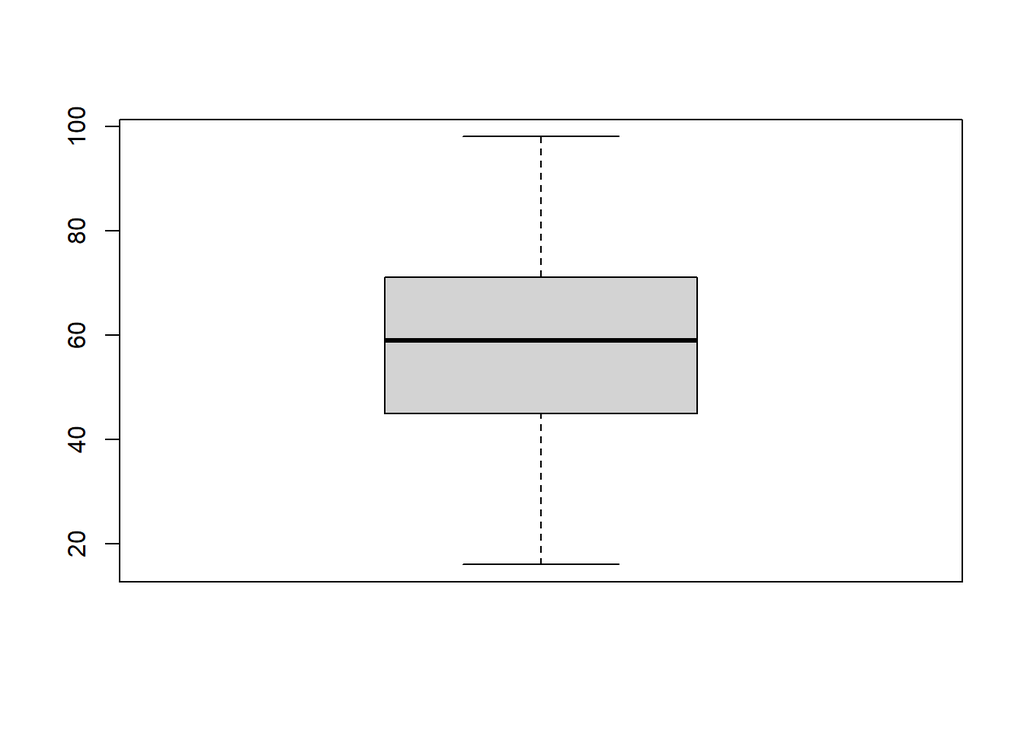

```r
boxplot(df_BIS$tot_score)
```

```r
# plot the histgram, with a size of width = 800mm, height = 600 mm, resolution is 300
png(here("figure","histogram_cog.png"), width = 800, height = 600,res = 300)
hist(df_BIS$cog)


dev.off()
```

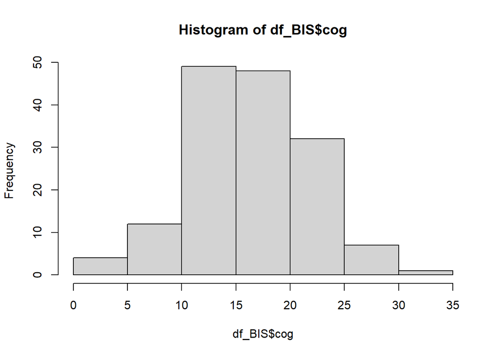

```
## $breaks
## [1]  0  5 10 15 20 25 30 35
##
## $counts
## [1]  4 12 49 48 32  7  1
##
## $density
## [1] 0.005228758 0.015686275 0.064052288 0.062745098 0.041830065 0.009150327
## [7] 0.001307190
##
## $mids
## [1]  2.5  7.5 12.5 17.5 22.5 27.5 32.5
##
## $xname
## [1] "df_BIS$cog"
##
## $equidist
## [1] TRUE
##
## attr(,"class")
## [1] "histogram"
```

```r
print(hist(df_BIS$cog))
```

## 4.5 Validate categorical variables

table () can tell you the unique values and their counts

```r
unique(df_BIS$rid)
```

```
##  [1]  1  2  3  4  5  6  7  8  9 10 11 12 13 14 15 16 17 18 19 20 21 22 23 24 25
## [26] 26 27 28 29 30 31 32 33 34 35 36 37 38 39 40 41 42 43 45 46 47 48 49 50 51
## [51] 52 53 54
```

```r
table(df_BIS$rid)  # table () can tell you the unique values and their counts
```

```
##
##  1  2  3  4  5  6  7  8  9 10 11 12 13 14 15 16 17 18 19 20 21 22 23 24 25 26
##  3  6  4  5  2  3  4  6  1  3  2  2  3  2  4  2  2  2  2  4  2  5  4  4  4  2
## 27 28 29 30 31 32 33 34 35 36 37 38 39 40 41 42 43 45 46 47 48 49 50 51 52 53
##  6  1  1  3  3  5  2  3  1  5  2  1  3  1  4  3  2  3  3  3  3  2  2  1  2  2
## 54
##  3
```

## 4.6 rename variables

use dplyr::rename() function, new_name = old_name

```r
df_BIS <- df_BIS %>%
  rename(
    participant_id = rid,
    cognition = cog,
    motor = mot
  )
```

## 4.7 compute row sums

- You can use the rowSums() function to compute the row sum.
- Use na.rm = TRUE to ignore NAs.
- For complex computation, you can use dplyr::select() to select your variables first, then compute.
- %>% is called the pipe operator, which looks like a series of logical steps.

```r
# for simple version
df_BIS$tot_score_q1_5 <- rowSums(df_BIS[, c("q1", "q2", "q3", "q4", "q5")], na.rm = TRUE)



df_BIS$total_score_q1_30 <- df_BIS %>%
  select(q1:q30) %>%    # select q1:q30
  rowSums(na.rm = TRUE)
```

## 4.8 reocode and transform variables

- You can use recode to relabel fixed values
- You can use case_when() function to add more complex conditions and transform data.

```r
df_BIS <- df_BIS %>%
  mutate(
    group = recode(group,
                   "1" = "patient",
                   "2" = "control")
  )



df_BIS <- df_BIS %>%
  mutate(
    score_level = case_when(   # new variable name is score_level
      total_score_q1_30 >= 0  & total_score_q1_30 < 20 ~ "low",
      total_score_q1_30 >= 20 & total_score_q1_30 <= 50 ~ "moderate",
      total_score_q1_30 > 50  ~ "high",
      TRUE ~ NA_character_  # handles missing or unexpected values
    )
  )
```

## 4.9 select variables and filter participants

You can use dylpr package to filter dataset with mutiple conditions. You can also use subset() function in Base R.

```r
df_BIS_baseline <-  df_BIS %>%
  filter(stage == "T0")

df_BIS_baseline_subset <-  df_BIS %>%
  filter(stage == "T0") %>%
  select(participant_id, group, cognition, motor, nonp, tot_score)

df_BIS_subset_baseline_patiens <-  df_BIS %>%
  filter(stage %in% c("T0","T1")) %>%
  select(participant_id, group, stage, cognition, motor, nonp, tot_score) %>%
  filter(group == "patients")

write.csv(df_BIS_baseline_subset,"output/df_BIS_baseline.csv")
```

## 4.10 merge two datasets into one

```r
head(df_BIS)
```

|  | participant_id | group | stage | q1 | q2 | q3 | q4 | q5 | q6 | q7 | q8 | q9 | q10 | q11 | q12 | q13 | q14 | q15 | q16 | q17 | q18 | q19 | q20 | q21 | q22 | q23 | q24 | q25 | q26 | … |
| --- | --- | --- | --- | --- | --- | --- | --- | --- | --- | --- | --- | --- | --- | --- | --- | --- | --- | --- | --- | --- | --- | --- | --- | --- | --- | --- | --- | --- | --- | --- |
| 1 | 1 | patient | T0 | 0 | 4 | 0 | 4 | 4 | 0 | 0 | 0 | 0 | 0 | 4 | 0 | 0 | 1 | 0 | 0 | 0 | 4 | 0 | 0 | 4 | 0 | 4 | 1 | 4 | 1 | … |
| 2 | 1 | patient | T1 | 0 | 1 | 0 | 4 | 3 | 1 | 0 | 0 | 0 | 0 | 1 | 1 | 0 | 0 | 3 | 4 | 0 | 4 | 0 | 0 | 3 | 3 | 3 | 3 | 1 | 1 | … |
| 3 | 1 | patient | T4 | 4 | 1 | 0 | 4 | 0 | 0 | 0 | 4 | 1 | 1 | 4 | 4 | 4 | 0 | 4 | 1 | 0 | 4 | 0 | 0 | 0 | 1 | 1 | 4 | 0 | 0 | … |
| 4 | 2 | patient | T0 | 4 | 1 | 4 | 4 | 4 | 4 | 3 | 4 | 4 | 1 | 3 | 4 | 4 | 0 | 4 | 3 | 0 | 4 | 1 | 1 | 4 | 4 | 4 | 4 | 0 | 4 | … |
| 5 | 2 | patient | T1 | 4 | 3 | 4 | 4 | 4 | 3 | 1 | 4 | 4 | 3 | 3 | 3 | 4 | 0 | 4 | 4 | 1 | 4 | 1 | 0 | 1 | 4 | 3 | 3 | 0 | 4 | … |
| 6 | 2 | patient | T1-4 | 4 | 0 | 4 | 4 | 4 | 4 | 3 | 3 | 4 | 3 | 3 | 3 | 4 | 0 | 4 | 0 | 0 | 3 | 3 | 0 | 1 | 3 | 3 | 0 | 0 | 3 | … |

```r
names(df_BIS)
```

```
##  [1] "participant_id"    "group"             "stage"
##  [4] "q1"                "q2"                "q3"
##  [7] "q4"                "q5"                "q6"
## [10] "q7"                "q8"                "q9"
## [13] "q10"               "q11"               "q12"
## [16] "q13"               "q14"               "q15"
## [19] "q16"               "q17"               "q18"
## [22] "q19"               "q20"               "q21"
## [25] "q22"               "q23"               "q24"
## [28] "q25"               "q26"               "q27"
## [31] "q28"               "q29"               "q30"
## [34] "cognition"         "motor"             "nonp"
## [37] "tot_score"         "tot_score_q1_5"    "total_score_q1_30"
## [40] "score_level"
```

```r
head(df_HDRS)
```

|  | rid | group | stage | q1 | q2 | q3 | q4 | q5 | q6 | q7 | q8 | q9 | q10 | q11 | q12 | q13 | q14 | q15 | q16_a | q16_b | q17 | tot_score | score_categories |
| --- | --- | --- | --- | --- | --- | --- | --- | --- | --- | --- | --- | --- | --- | --- | --- | --- | --- | --- | --- | --- | --- | --- | --- |
| 1 | 1 | 1 | T0 | 0 | 0 | 0 | 2 | 1 | 1 | 0 | 0 | 0 | 1 | 0 | 0 | 0 | 0 | 0 | 0 | 0 | 1 | 6 | 1 |
| 2 | 1 | 1 | T1 | 0 | 0 | 0 | 0 | 0 | 0 | 0 | 1 | 0 | 1 | 0 | 0 | 0 | 0 | 0 | 0 | 0 | 1 | 3 | 1 |
| 3 | 1 | 1 | T4 | 0 | 1 | 0 | 0 | 0 | 0 | 0 | 0 | 0 | 0 | 0 | 0 | 0 | 0 | 0 | 0 | 0 | 0 | 1 | 1 |
| 4 | 2 | 1 | T0 | 1 | 2 | 0 | 1 | 0 | 0 | 1 | 0 | 1 | 2 | 2 | 0 | 1 | 0 | 0 | 0 | 0 | 1 | 12 | 2 |
| 5 | 2 | 1 | T1 | 1 | 0 | 0 | 0 | 0 | 0 | 1 | 0 | 1 | 1 | 2 | 0 | 1 | 0 | 0 | 0 | 0 | 0 | 7 | 1 |
| 6 | 2 | 1 | T1-4 | 1 | 1 | 0 | 1 | 1 | 0 | 1 | 0 | 0 | 1 | 1 | 0 | 0 | 0 | 0 | 0 | 0 | 0 | 7 | 1 |

```r
names(df_HDRS)
```

```
##  [1] "rid"              "group"            "stage"            "q1"
##  [5] "q2"               "q3"               "q4"               "q5"
##  [9] "q6"               "q7"               "q8"               "q9"
## [13] "q10"              "q11"              "q12"              "q13"
## [17] "q14"              "q15"              "q16_a"            "q16_b"
## [21] "q17"              "tot_score"        "score_categories"
```

You can use merge()function to merge two datasets by some common variables. Make sure that the key variable names are the same in the two datasets.

```r
# rename the rid in the HDRS dataset
df_HDRS <- df_HDRS %>%
  rename("participant_id" = "rid")

# merge two datasets based on common variables like participate id and stage
df_merged <- merge(df_BIS,df_HDRS, by = c("participant_id","stage"),all = TRUE)
```

## 4.11 save the merged dataset

```r
write.csv(df_merged,here("output","df_merged.csv"))

write_sav(df_merged,here("output","df_merged.sav"))    # save the data as sav file, which is readable in SPSS.
```

# 5 Create your table 1

You can find more details here: https://cran.r-project.org/web/packages/table1/vignettes/table1-examples.html

```r
# To create the table 1 according to the group (patient and control)

table1(~  cognition + motor | group, data=df_BIS_baseline_subset)
```

|  | patient (N=23) | control (N=30) | Overall (N=53) |
| --- | --- | --- | --- |
| cognition |  |  |  |
| Mean (SD) | 18.2 (5.57) | 18.6 (5.48) | 18.4 (5.47) |
| Median [Min, Max] | 17.0 [8.00, 26.0] | 19.0 [4.00, 28.0] | 19.0 [4.00, 28.0] |
| motor |  |  |  |
| Mean (SD) | 19.0 (7.23) | 20.7 (7.67) | 19.9 (7.46) |
| Median [Min, Max] | 19.0 [7.00, 33.0] | 21.0 [5.00, 36.0] | 20.0 [5.00, 36.0] |